# Week 11: Markov Chains

STAT 536 — Statistical Computing

Soumojit Das

Fall 2026

# The Idea

## Where We Are

- Weeks 1 to 4: $f$ known. The problem was to sample from it and to integrate against it.
- Week 7: the posterior written down, $\pi(\theta \mid \mathbf{x}) \propto L(\theta)\,\pi(\theta)$.
- The posterior is known only up to a constant.
- This block builds samplers for it: Markov chain Monte Carlo (MCMC).
- The path: Markov chains, Metropolis, Metropolis–Hastings, Gibbs, Hamiltonian Monte Carlo, then Stan.

where $f$: a density fixed by the question; $\theta$: the unknown; $\mathbf{x}$: the observed data; $L(\theta)$: the likelihood; $\pi(\theta)$: the prior density; $\pi(\theta \mid \mathbf{x})$: the posterior density.

## The Target

$$\pi(\theta \mid \mathbf{x}) = \frac{L(\theta)\,\pi(\theta)}{m(\mathbf{x})} \propto L(\theta)\,\pi(\theta)$$

- Generate samples $\theta^{(1)}, \theta^{(2)}, \ldots, \theta^{(N)}$ from $\pi(\theta \mid \mathbf{x})$ even though we only know $\pi(\theta \mid \mathbf{x})$ up to a normalizing constant.
- **Posterior mean:** $\E[\theta \mid \mathbf{x}] \approx \frac{1}{N}\sum_{t=1}^N \theta^{(t)}$.
- **Posterior quantiles:** use empirical quantiles.
- **Posterior probabilities:** $P(\theta \in A \mid \mathbf{x}) \approx \frac{1}{N}\sum_{t=1}^N \mathbb{I}(\theta^{(t)} \in A)$.
- **Any functional:** $\E[h(\theta) \mid \mathbf{x}] \approx \frac{1}{N}\sum_{t=1}^N h(\theta^{(t)})$.

where $\theta$: the unknown; $\theta^{(t)}$: draw number $t$; $N$: the number of draws; $\mathbf{x}$: the observed data; $L(\theta)$: the likelihood; $\pi(\theta)$: the prior density; $m(\mathbf{x}) = \int L(\theta)\,\pi(\theta)\,d\theta$: the normalizing constant; $A$: a set of values of $\theta$; $\mathbb{I}(\cdot)$: 1 if the statement inside holds, 0 otherwise; $h$: a function of $\theta$.

## Accept-Reject in $d$ Dimensions

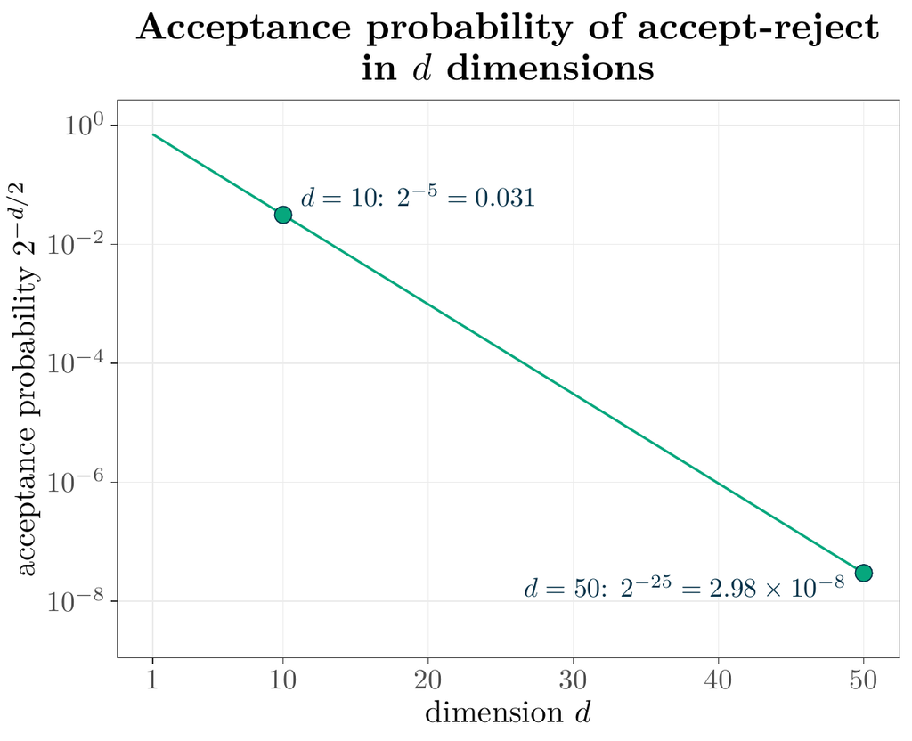

- Recall accept-reject from week 3? It needs a proposal $g$ and a bound $M$ on target over proposal, for all $\boldsymbol\theta$.
- Target $f = \Normal(\mathbf{0}, \mathbf{I})$, proposal $g = \Normal(\mathbf{0}, 2\mathbf{I})$: $f/g = 2^{d/2}e^{-\|\boldsymbol\theta\|^2/4} \le 2^{d/2} = M$, so the acceptance probability is $1/M = 2^{-d/2}$.
- Line: that probability against $d$, log axis.
- $d = 10$: 3.1%. $d = 50$: about 34 million proposals per accepted draw. Accept-reject breaks down as $d$ grows.

where $d$: the dimension of the target; $\boldsymbol\theta$: the unknown, a point of $\mathbb{R}^d$; $\|\boldsymbol\theta\|^2$: its squared length; $\mathbf{0}$, $\mathbf{I}$: the zero vector and the identity matrix.

## From Independence to Dependence

- **Traditional Monte Carlo.** $\theta^{(1)}, \ldots, \theta^{(N)} \iid \pi(\theta \mid \mathbf{x})$: samples are independent, and we need to sample directly from the target.
- **MCMC.** $\theta^{(1)}, \ldots, \theta^{(N)}$ is a Markov chain with stationary distribution $\pi(\theta \mid \mathbf{x})$: samples are dependent, and we only need to sample from simple proposals.

**Key Idea**

Instead of independent samples, generate **dependent** samples via a Markov chain designed to have the target distribution as its stationary distribution.

where $\theta^{(t)}$: draw number $t$; $N$: the number of draws; $\pi(\theta \mid \mathbf{x})$: the posterior density, the target.

# Markov Chains

## Markov Chain: Definition

- A sequence $X_0, X_1, X_2, \ldots$ with values in a state space $\mathcal{S}$ is a **Markov chain** if, for all $t \ge 0$, all sets $A \subseteq \mathcal{S}$, and all states $x_0, \ldots, x_t$:

$$P(X_{t+1} \in A \mid X_t = x_t, X_{t-1} = x_{t-1}, \ldots, X_0 = x_0) = P(X_{t+1} \in A \mid X_t = x_t)$$

- Essentially, this says that the future depends on the past only through the present.
- **Time-homogeneous:** $P(X_{t+1} \in A \mid X_t = x)$ does not depend on $t$ (assumed from here on).

where $X_t$: the state at time $t$; $\mathcal{S}$: the set of possible states; $A$: a set of states; $x_0, \ldots, x_t$, $x$: states.

## Discrete State Space: The Transition Matrix

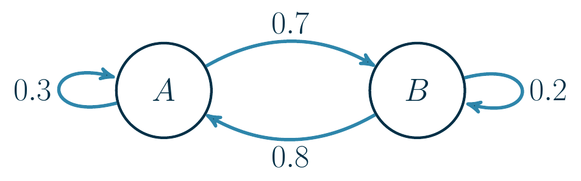

$$\mathbf{P} = \begin{pmatrix} 0.3 & 0.7 \\ 0.8 & 0.2 \end{pmatrix}$$

- Circles: the states $A$ and $B$. Arrows: the moves, with their probabilities.
- $P_{ij} = P(X_{t+1} = j \mid X_t = i)$: row $i$, column $j$.
- Rows sum to 1: $\sum_j P_{ij} = 1$.
- The two-state chain: $P_{AB} = 0.7$, $P_{BA} = 0.8$.

where $\mathbf{P}$: the transition matrix, states in the order $A$, $B$; $i$, $j$: states; $X_t$: the state at time $t$.

## Continuous State Space: The Transition Density

$$P(X_{t+1} \in A \mid X_t = x) = \int_A K(x, y)\,dy, \qquad \int K(x, y)\,dy = 1$$

- **Random walk on $\mathbb{R}$.** $X_{t+1} = X_t + \epsilon_{t+1}$, with $\epsilon_{t+1} \sim \Normal(0, 1)$.
- State space: $\mathbb{R}$. Transition density: $K(x, y) = \phi(y; x, 1)$.
- Each increment is independent of the past, so the future depends on the past only through the present.
- In MCMC the state is the unknown $\theta$: the state space is continuous when $\theta$ is.

where $X_t$: the state at time $t$; $K(x, y)$: the transition density, from $x$ to $y$; $A$: a set of states; $\epsilon_{t+1}$: the increment; $\phi(y; m, s^2)$: the $\Normal(m, s^2)$ density at $y$.

## The Distribution at Time $t$

$$\begin{aligned}
(\boldsymbol\mu_{t+1})_j = P(X_{t+1} = j) &= \sum_i P(X_t = i)\,P(X_{t+1} = j \mid X_t = i) \\
&= \sum_i (\boldsymbol\mu_t)_i\,P_{ij} = (\boldsymbol\mu_t\mathbf{P})_j
\end{aligned}$$

- $\boldsymbol\mu_{t+1} = \boldsymbol\mu_t\mathbf{P}$, so $\boxed{\boldsymbol\mu_t = \boldsymbol\mu_0\mathbf{P}^t}$, and $(\mathbf{P}^t)_{ij} = P(X_t = j \mid X_0 = i)$.
- On a continuous state space, $\mu_{t+1}(y) = \int \mu_t(x)K(x, y)\,dx$.
- Essentially, this says that each step multiplies the row vector of probabilities by $\mathbf{P}$.

where $X_t$: the state at time $t$; $\boldsymbol\mu_t$: its distribution, a row vector; $\mu_t(x)$: its density; $i$, $j$: states; $\mathbf{P}$: the transition matrix with entries $P_{ij}$; $K(x, y)$: the transition density.

## The Two-State Chain by Hand

$$\mathbf{P} = \begin{pmatrix} 0.3 & 0.7 \\ 0.8 & 0.2 \end{pmatrix}, \qquad \boldsymbol\mu_0 = (1, 0)$$

$$\begin{aligned}
\boldsymbol\mu_1 &= (1, 0)\,\mathbf{P} = (0.3,\ 0.7) \\
\boldsymbol\mu_2 &= (0.3,\ 0.7)\,\mathbf{P} = (0.65,\ 0.35) \\
\boldsymbol\mu_3 &= (0.65,\ 0.35)\,\mathbf{P} = (0.475,\ 0.525) \\
\boldsymbol\mu_4 &= (0.475,\ 0.525)\,\mathbf{P} = (0.5625,\ 0.4375)
\end{aligned}$$

- $P(X_t = A)$ runs 1, 0.3, 0.65, 0.475, 0.5625: above and below one value, by less at each step.

where $\boldsymbol\mu_t = (P(X_t = A),\ P(X_t = B))$; $\mathbf{P}$: the transition matrix, states in the order $A$, $B$.

# The AR(1) Model

## AR(1): The Model

$$X_{t+1} = \rho X_t + \epsilon_{t+1}, \qquad \epsilon_1, \epsilon_2, \ldots \iid \Normal(0, \sigma^2)$$

- **AR(1)**, the autoregressive process of order 1: the next state is a regression on the current one, with slope $\rho$ and no intercept.
- Each state is $\rho$ times the last one, plus fresh noise: $\rho$ is how much of the current state carries over, $\sigma^2$ how much new noise enters.
- Each $\epsilon_{t+1}$ is independent of $X_0, \ldots, X_t$, so given $X_t = x$ only the noise is random: $X_{t+1} \mid X_t = x \sim \Normal(\rho x, \sigma^2)$.
- The transition density is $K(x, y) = \phi(y; \rho x, \sigma^2)$, on the state space $\mathbb{R}$.
- The example throughout: $\rho = 0.9$, $\sigma^2 = 1$. From $x = 17$, the next state is $\Normal(15.3, 1)$: a pull toward 0.

where $X_t$: the state at time $t$; $\rho$: the AR(1) coefficient; $\epsilon_{t+1}$: the noise of step $t + 1$; $\sigma^2$: its variance; $K(x, y)$: the transition density; $\phi(y; m, s^2)$: the $\Normal(m, s^2)$ density at $y$.

## AR(1) Is a Markov Chain

- Recall AR(1): $X_t = \rho X_{t-1} + \epsilon_t$, with $\epsilon_t \sim \Normal(0, \sigma^2)$ independent of $X_{t-1}, \ldots, X_0$. Condition on the whole past:

$$\begin{aligned}
P(X_t \le x \mid X_{t-1} = x_{t-1}, \ldots, X_0 = x_0) &= P(\rho x_{t-1} + \epsilon_t \le x \mid X_{t-1} = x_{t-1}, \ldots, X_0 = x_0) \\
&= P(\epsilon_t \le x - \rho x_{t-1}) \quad \text{(by independence)} \\
&= \Phi\left(\frac{x - \rho x_{t-1}}{\sigma}\right) \\
&= \boxed{P(X_t \le x \mid X_{t-1} = x_{t-1})}
\end{aligned}$$

- This distribution depends only on $x_{t-1}$ and not on $x_{t-2}, \ldots, x_0$.

where $X_t$: the state at time $t$; $x$, $x_0, \ldots, x_{t-1}$: numbers; $\epsilon_t \sim \Normal(0, \sigma^2)$: the noise, independent of $X_{t-1}, \ldots, X_0$; $\rho$: the AR(1) coefficient; $\Phi$: the standard normal CDF.

## AR(1) from Two Starts

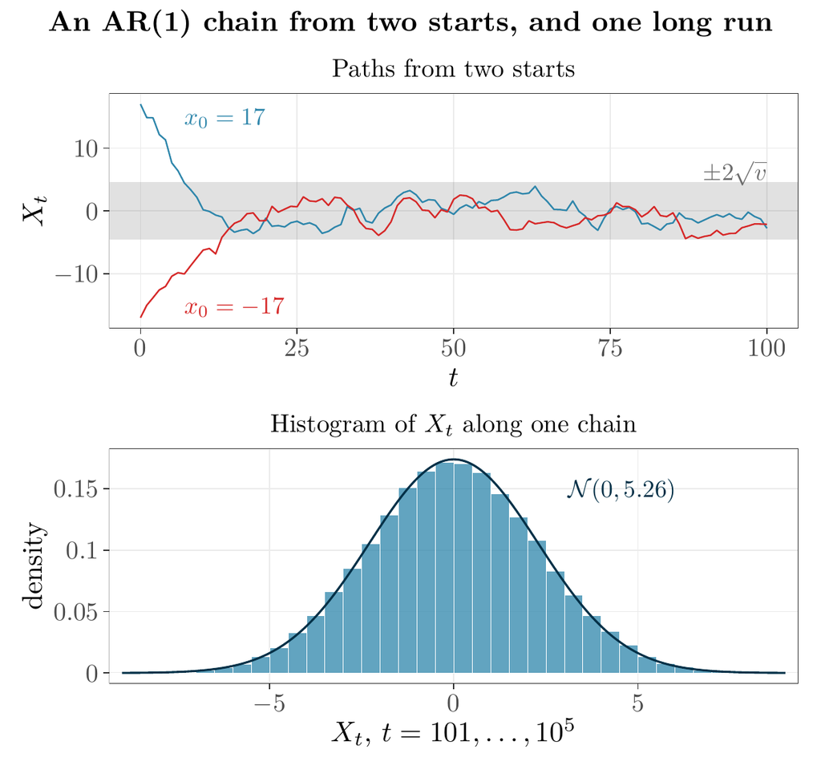

- Recall AR(1) at $\rho = 0.9$, $\sigma^2 = 1$: $X_{t+1} = 0.9\,X_t + \epsilon_{t+1}$.
- Top: trace plots of two runs, from 17 (blue) and $-17$ (red). Grey band: $\pm 2\sqrt{v} = \pm 4.59$.
- Bottom: one run of $10^5$ steps, first 100 discarded. Dark curve: $\Normal(0, v)$.
- By $t = 13$ both runs are in the band. Long run: mean 0.01, variance 5.39, against 0 and $v$.
- The start is forgotten. MCMC: engineer a chain whose long-run distribution is the posterior.

where $X_t$: the state at time $t$; $\epsilon_t$: the noise; $v = 1/(1 - 0.9^2) = 5.26$.

## AR(1) at Time $t$

$$\begin{aligned}
X_t &= \rho X_{t-1} + \epsilon_t = \rho^2 X_{t-2} + \rho\,\epsilon_{t-1} + \epsilon_t = \cdots = \rho^t x_0 + \sum_{s=0}^{t-1}\rho^s\epsilon_{t-s} \\
\E(X_t \mid X_0 = x_0) &= \rho^t x_0 \quad \text{(each noise has mean 0)} \\
\Var(X_t \mid X_0 = x_0) &= \sigma^2\sum_{s=0}^{t-1}\rho^{2s} = \sigma^2\,\frac{1 - \rho^{2t}}{1 - \rho^2} \quad \text{(geometric series, ratio } \rho^2\text{)}
\end{aligned}$$

$$\boxed{X_t \mid X_0 = x_0 \sim \Normal\Bigl(\rho^t x_0,\ \sigma^2\,\frac{1 - \rho^{2t}}{1 - \rho^2}\Bigr)}$$

- Normal: a linear combination of independent normals is normal.
- Essentially, this says that the mean forgets $x_0$ at the rate $\rho^t$ while the variance climbs to a limit.

where $X_t$: the state at time $t$; $\rho$: the AR(1) coefficient, $\lvert\rho\rvert < 1$; $\epsilon_t \iid \Normal(0, \sigma^2)$: the noise; $x_0$: the start; $s$: the summation index.

## AR(1): Densities at Increasing $t$

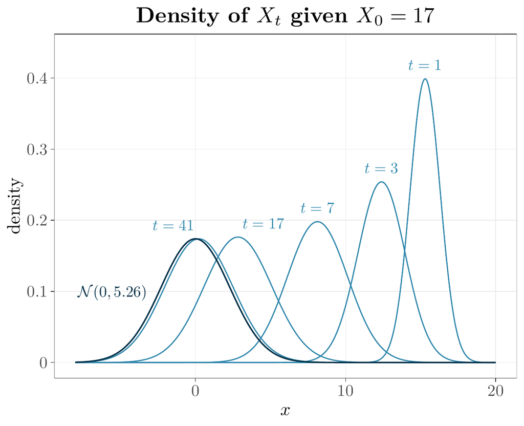

- Recall the law at time $t$. At $\rho = 0.9$, $\sigma^2 = 1$, from $x_0 = 17$: $X_t \sim \Normal\bigl(17(0.9)^t,\ 5.26(1 - 0.81^t)\bigr)$.
- Blue: this density at $t = 1, 3, 7, 17, 41$. Dark: the limit $\Normal(0, 5.26)$.
- $t = 1$: mean 15.30, variance 1.00. $t = 41$: mean 0.23, variance 5.26.
- The center slides to 0 at rate $0.9^t$. The spread grows to its limit.

where $X_t$: the AR(1) chain; $\rho$: its coefficient; $\sigma^2$: its noise variance; $x_0$: the start; $x$: a value of $X_t$.

# Stationary Distributions

## Stationary Distribution: Definition

- $\boldsymbol\pi$ is **stationary** for $\mathbf{P}$ if $\boldsymbol\pi = \boldsymbol\pi\mathbf{P}$, that is $\pi_j = \sum_i \pi_i P_{ij}$ for all $j$.
- On a continuous state space, $\pi(y) = \int \pi(x)K(x, y)\,dx$ for all $y$.
- If $X_t \sim \pi$, then $X_{t+1} \sim \pi$.
- Discrete case: $\boldsymbol\pi$ is a left eigenvector of $\mathbf{P}$ with eigenvalue 1.
- Essentially, this says that the distribution is preserved by the transition.

where $\boldsymbol\pi$: a row vector of probabilities with entries $\pi_i$; $\mathbf{P}$: the transition matrix with entries $P_{ij}$; $\pi(x)$: a density; $K(x, y)$: the transition density; left eigenvector: a row vector that $\mathbf{P}$ multiplies from the right.

## Solving $\boldsymbol\pi = \boldsymbol\pi\mathbf{P}$

- Recall the two-state chain, and write the unknown as $\boldsymbol\pi = (\pi_A, \pi_B)$:

$$\mathbf{P} = \begin{pmatrix} 0.3 & 0.7 \\ 0.8 & 0.2 \end{pmatrix}, \qquad \boldsymbol\pi\mathbf{P} = \bigl(0.3\,\pi_A + 0.8\,\pi_B,\ \ 0.7\,\pi_A + 0.2\,\pi_B\bigr)$$

- Set $\boldsymbol\pi\mathbf{P} = \boldsymbol\pi$, entry by entry. The first entry gives:

$$\pi_A = 0.3\,\pi_A + 0.8\,\pi_B \ \Rightarrow\ \pi_B = \tfrac{7}{8}\,\pi_A, \qquad \pi_A + \pi_B = 1 \ \Rightarrow\ \boxed{\boldsymbol\pi = \bigl(\tfrac{8}{15},\ \tfrac{7}{15}\bigr)}$$

- The second entry repeats the first: the probabilities summing to 1 is what fixes the scale.
- $8/15 = 0.533$ is the value that $P(X_t = A)$ swings around: each step multiplies the gap to it by $-0.5$.

where $\boldsymbol\pi$: the stationary distribution; $\pi_A$, $\pi_B$: the stationary probabilities of $A$ and $B$; $\mathbf{P}$: the transition matrix, states in the order $A$, $B$; $X_t$: the state at time $t$.

## AR(1): The Stationary Distribution

- Recall AR(1), $X_{t+1} = \rho X_t + \epsilon_{t+1}$, and that $\pi$ is stationary if $X_t \sim \pi$ gives $X_{t+1} \sim \pi$.
- If $X_t \sim \Normal(m, v)$, then $X_{t+1} \sim \Normal(\rho m,\ \rho^2 v + \sigma^2)$.
- Stationarity needs the same mean and the same variance, which requires $\lvert\rho\rvert < 1$:

$$m = \rho m \ \Rightarrow\ m = 0, \qquad v = \rho^2 v + \sigma^2 \ \Rightarrow\ \boxed{v = \frac{\sigma^2}{1 - \rho^2}}$$

- Recall $X_t \mid X_0 = x_0 \sim \Normal\bigl(\rho^t x_0,\ \sigma^2\frac{1 - \rho^{2t}}{1 - \rho^2}\bigr)$: its limit is the same distribution, since $\rho^t x_0 \to 0$ and $\sigma^2\frac{1 - \rho^{2t}}{1 - \rho^2} \to \frac{\sigma^2}{1 - \rho^2}$.
- At $\rho = 0.9$, $\sigma^2 = 1$: $\Normal(0, 5.26)$. Essentially, this says that the pull toward 0 and the fresh noise balance at the variance $v$.

where $X_t$: the state at time $t$; $\rho$: the AR(1) coefficient; $\epsilon_{t+1} \sim \Normal(0, \sigma^2)$: the noise, independent of $X_t$; $m$, $v$: the mean and the variance of $X_t$; $x_0$: the start.

## Parallel Chains from $\pi$

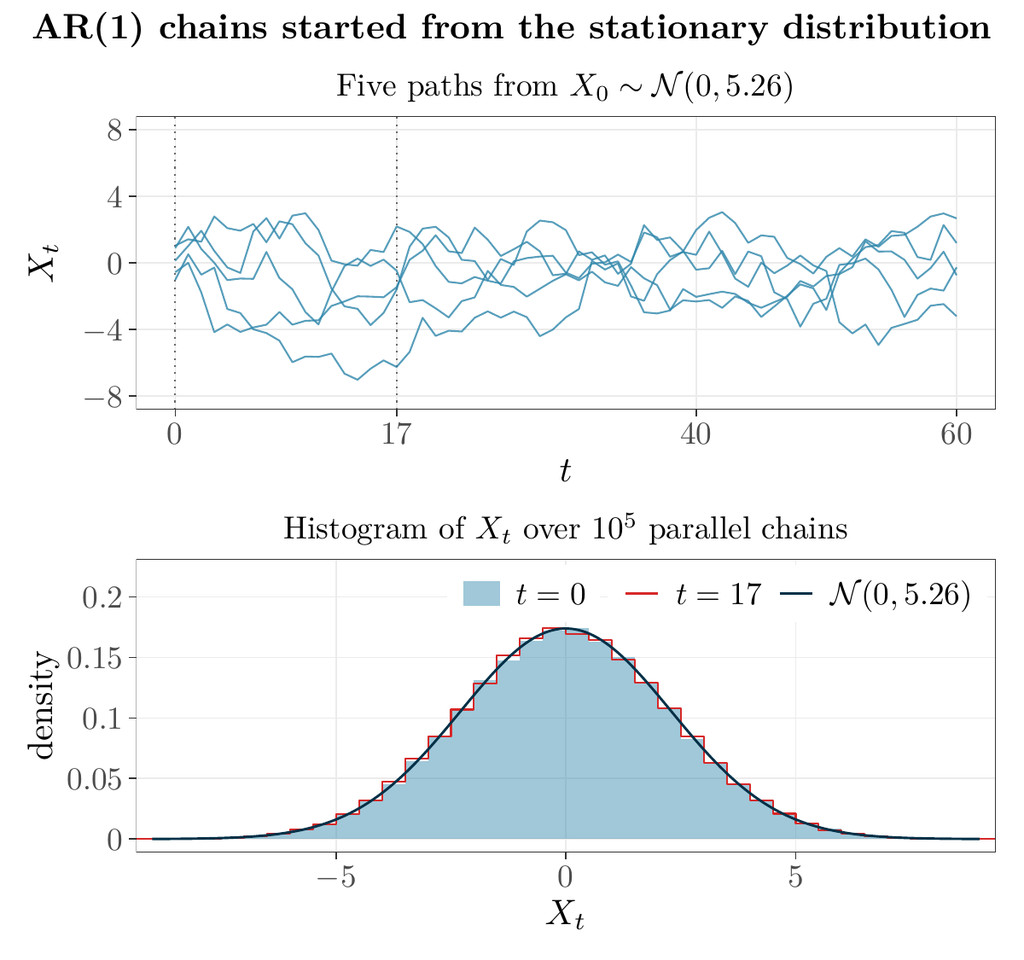

- Recall AR(1) at $\rho = 0.9$, $\sigma^2 = 1$: $\pi = \Normal(0, 5.26)$. Top: five runs started from $\pi$. Dotted: $t = 0$ and $t = 17$.
- Bottom: $10^5$ parallel runs: histogram at $t = 0$ (blue), outline at $t = 17$ (red). Dark: $\pi$.
- Variance across runs: 5.30 at $t = 0$, 5.27 at $t = 17$.
- The distribution is preserved. Each chain keeps moving.

where $X_t$: the state of a run at time $t$; $\rho$: the AR(1) coefficient; $\sigma^2$: the noise variance.

## What $\rho$ Does

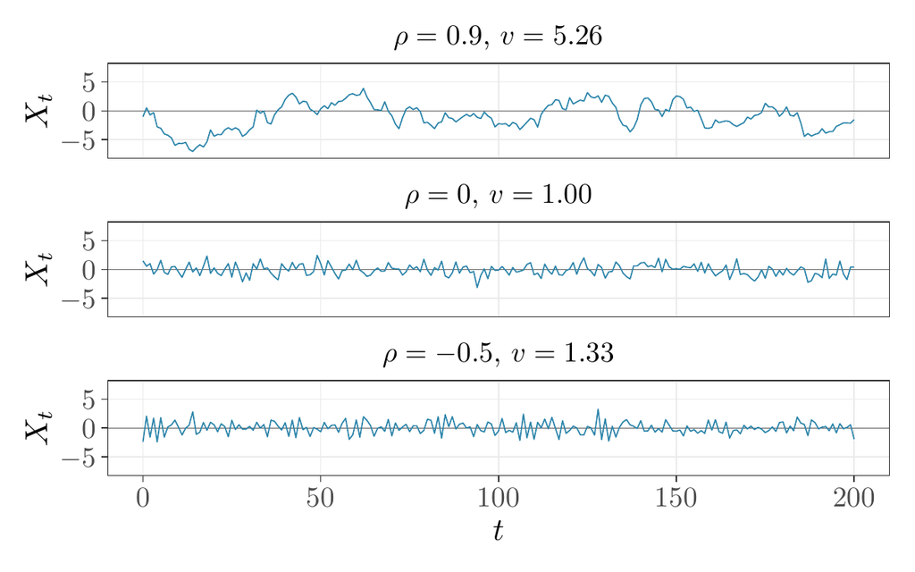

- Recall $X_{t+1} = \rho X_t + \epsilon_{t+1}$, $\pi = \Normal(0, v)$. Runs of 200 steps from $\pi$, $\sigma^2 = 1$: top to bottom, $\rho = 0.9$, $0$, $-0.5$.
- $\rho = 0.9$: long stretches on one side of 0. $\rho = 0$: independent draws. $\rho = -0.5$: the sign keeps flipping.
- From $\pi$, $\mathrm{Corr}(X_t, X_{t+k}) = \rho^k$. At lag 10: 0.35, 0, and 0.001.
- **The role of $\rho$:** it sets the chain’s memory. The larger $\lvert\rho\rvert$, the more of each state carries into the next and the slower the start is forgotten. Its sign decides whether the chain lingers on one side of 0 or flips.

where $X_t$: the state at time $t$; $\rho$: the AR(1) coefficient; $\epsilon_{t+1}$: the noise; $\sigma^2$: its variance; $v = \sigma^2/(1 - \rho^2)$; $k$: a lag.

## Three Key Questions

|  | Question | Why it matters computationally |
| --- | --- | --- |
| **Existence** | Does a stationary distribution exist? | Our target can be a stationary distribution |
| **Uniqueness** | Is it unique? | We’ll get the right answer |
| **Convergence** | Do we reach it from any starting point? | The starting point does not affect the limit |

- On a finite state space one always exists. On $\mathbb{R}$ it may not: under AR(1) at $\rho = 1$, the random walk $X_{t+1} = X_t + \epsilon_{t+1}$, a stationary distribution with finite variance $v$ would need $v = v + \sigma^2$.

where $\rho$: the AR(1) coefficient; $v$: the stationary variance; $\epsilon_{t+1}$: the noise; $\sigma^2$: its variance.

# Irreducibility

## Irreducibility

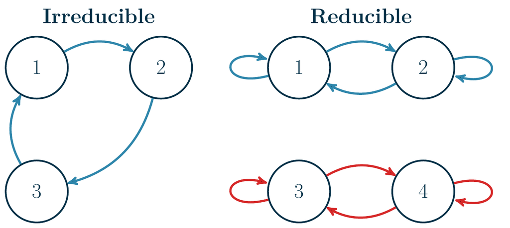

- Essentially, this says that the chain can eventually reach any positive-probability region from anywhere: no isolated islands.
- Circles: states. Arrows: moves with positive probability.
- Left: **irreducible**, can reach any state from any other. Right: reducible, two disconnected components.
- Discrete: for every pair of states $i, j$ there is a $t \ge 1$ with $(\mathbf{P}^t)_{ij} > 0$.
- Continuous, with state space $\{x : \pi(x) > 0\}$: from every start $x$ in it, every set $A$ with $\pi(A) > 0$ has $P(X_t \in A \mid X_0 = x) > 0$ for some $t \ge 1$.

where 1, 2, 3, 4: the states; $(\mathbf{P}^t)_{ij}$: the $t$-step probability; $\pi(x)$: the target density; $\pi(A)$: the probability $\pi$ gives $A$; $X_t$: the state at time $t$.

## Irreducibility and Uniqueness

- If an irreducible Markov chain has a stationary distribution, that distribution is unique. On a finite or countable state space, it gives every state positive probability.
- Essentially, this says that a connected chain has at most one equilibrium.
- The reducible chain, with every move of probability 1/2:

$$\mathbf{P} = \begin{pmatrix} 0.5 & 0.5 & 0 & 0 \\ 0.5 & 0.5 & 0 & 0 \\ 0 & 0 & 0.5 & 0.5 \\ 0 & 0 & 0.5 & 0.5 \end{pmatrix}$$

- It has stationary distributions $\bigl(\frac{c}{2}, \frac{c}{2}, \frac{1-c}{2}, \frac{1-c}{2}\bigr)$ for every $c \in [0, 1]$.
- From state 1 or 2 the limit is $(1/2, 1/2, 0, 0)$. From state 3 or 4 it is $(0, 0, 1/2, 1/2)$: the starting point determines limiting behavior.

where $\mathbf{P}$: the transition matrix on states 1, 2, 3, 4; $c$: the total probability on states 1 and 2.

# Convergence and Averages

## Aperiodicity

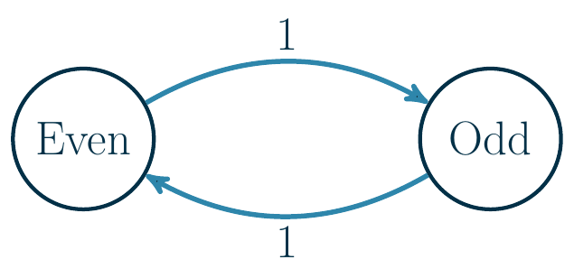

$$\mathbf{P} = \begin{pmatrix} 0 & 1 \\ 1 & 0 \end{pmatrix}, \qquad \boldsymbol\pi = \bigl(\tfrac12,\ \tfrac12\bigr)$$

- Essentially, a chain of period $d$ returns only at multiples of $d$, so $\boldsymbol\mu_t$ can cycle forever.
- **Period.** $d(i) = \gcd\{t \ge 1 : (\mathbf{P}^t)_{ii} > 0\}$. A chain is aperiodic if $d(i) = 1$ for every state $i$.
- Even/Odd: returns to Even only in even steps, so $d = 2$. $\boldsymbol\mu_t$ alternates $(1, 0), (0, 1), \ldots$ forever, and $\boldsymbol\pi = (1/2, 1/2)$ is never reached.
- All states of an irreducible chain have the same period, so one state with $P_{ii} > 0$ makes it aperiodic.
- On a continuous state space, aperiodic means no cycling through $d \ge 2$ disjoint regions.

where gcd: greatest common divisor; $\mathbf{P}$: the transition matrix of Even/Odd; $(\mathbf{P}^t)_{ii}$: the $t$-step return probability; $P_{ii}$: the probability of staying at $i$; $\boldsymbol\mu_t$: the distribution of $X_t$; $\boldsymbol\pi$: the stationary distribution.

## Return Times and Positive Recurrence

- **Return time.** $\tau_i = \min\{t \ge 1 : X_t = i\}$. State $i$ is **positive recurrent** if $\E[\tau_i \mid X_0 = i] < \infty$. In an irreducible chain all states share the property, and we say the chain has it.
- On a finite or countable state space, an irreducible chain has a stationary distribution if and only if it is positive recurrent, and then $\pi_i = 1/\E[\tau_i \mid X_0 = i]$: a return every $m$ steps on average is a fraction $1/m$ of the time.
- Check on the two-state chain:

$$\mathbf{P} = \begin{pmatrix} 0.3 & 0.7 \\ 0.8 & 0.2 \end{pmatrix}, \quad \boldsymbol\pi = \bigl(\tfrac{8}{15},\ \tfrac{7}{15}\bigr), \quad \E[\tau_A \mid X_0 = A] = 0.3 \cdot 1 + 0.7\Bigl(1 + \frac{1}{0.8}\Bigr) = \frac{15}{8} = \frac{1}{\pi_A}$$

- On a continuous state space, a chain that leaves a point returns to that exact point with probability 0. There, **positive recurrent** means that a stationary distribution exists (Tierney, 1994).

where $\tau_i$: the return time to $i$; $X_t$: the state at time $t$; $\pi_i$: the stationary probability of $i$; 0.3: the probability of staying at $A$; 0.7: of moving to $B$, then a geometric wait with mean $1/0.8$.

## The Fundamental Theorem

- A Markov chain is **ergodic** if it is irreducible, aperiodic, and positive recurrent.

**Fundamental Theorem of Markov Chains**

An ergodic Markov chain on a finite or countable state space has a unique stationary distribution $\boldsymbol\pi$, and $\lim_{t \to \infty}(\mathbf{P}^t)_{ij} = \pi_j$ for all states $i, j$.

- Essentially, this says that the starting point doesn’t matter in the limit.
- For a Metropolis chain on a continuous state space, with target $\pi$: if the chain is irreducible and aperiodic, then $P(X_t \in A \mid X_0 = x) \to \pi(A)$ for every set $A$ and every start $x$ with $\pi(x) > 0$ (Tierney, 1994).

where $(\mathbf{P}^t)_{ij}$: the $t$-step probability from $i$ to $j$; $\pi_j$: the stationary probability of $j$; $\pi(x)$: the target density; $\pi(A)$: the probability $\pi$ gives the set $A$; Metropolis chain: proposes a new state, accepts it with a probability, otherwise stays.

## How Fast It Converges

- Recall the two-state chain, $\mathbf{P} = \bigl(\begin{smallmatrix} 0.3 & 0.7 \\ 0.8 & 0.2 \end{smallmatrix}\bigr)$, $\boldsymbol\pi = \bigl(\tfrac{8}{15}, \tfrac{7}{15}\bigr)$, and AR(1), $X_{t+1} = 0.9\,X_t + \epsilon_{t+1}$, $\pi = \Normal(0, 5.26)$.

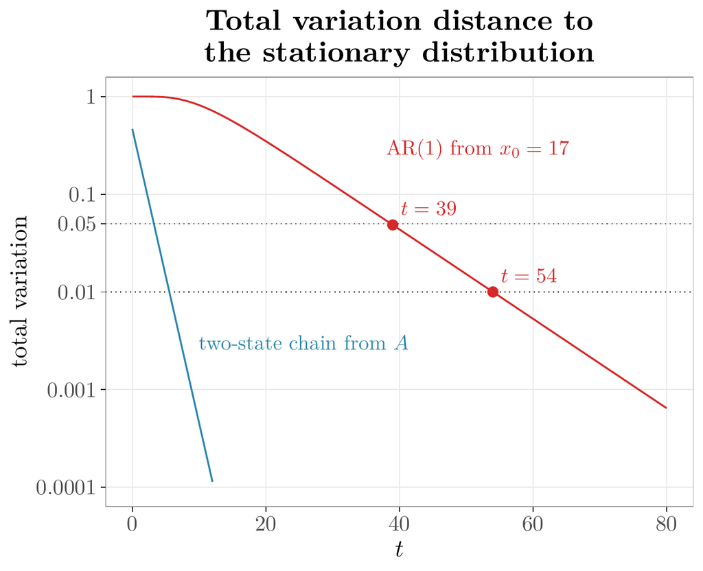

- Total variation to $\pi$ against $t$, log axis. Dotted: 0.05 and 0.01, which AR(1) from $x_0 = 17$ reaches at $t = 39$ and $t = 54$.
- A chain is **geometrically ergodic** if, for some $r < 1$ and finite $C(x)$, the distance from every start $x$ is at most $C(x)\,r^t$, a straight line on a log axis: here $r = 0.5$, since each step multiplies the two-state gap by $-0.5$, and $r = \rho = 0.9$.
- At finite $t$ the start still matters: this is why we discard a burn-in.

where total variation: the largest difference in the probability of an event (week 8); $\pi$: each chain’s stationary distribution; $\epsilon_{t+1}$: the noise, variance 1; $\rho$: the AR(1) coefficient; burn-in: the first stretch of the run.

## Ergodic Theorem

**Ergodic Theorem**

Let a chain on a finite or countable state space be irreducible and positive recurrent with stationary distribution $\pi$, and let $\E_\pi[|h(X)|] < \infty$. Then $\bar h_N = \frac1N\sum_{t=1}^N h(X_t) \to \E_\pi[h(X)]$ with probability one as $N \to \infty$, from every starting state. Aperiodicity is not needed.

- Essentially, this says that sample averages converge to expectations under $\pi$, even though samples are dependent.
- Recall the SLLN of week 1? The same conclusion, for independent draws.
- Recall the two-state chain, $\mathbf{P} = \bigl(\begin{smallmatrix} 0.3 & 0.7 \\ 0.8 & 0.2 \end{smallmatrix}\bigr)$, $\boldsymbol\pi = \bigl(\tfrac{8}{15}, \tfrac{7}{15}\bigr)$. With $h = 1$ at $A$ and 0 at $B$, $N = 10^6$: the fraction of time at $A$ is 0.533, against $\pi_A = 0.533$.
- A Metropolis chain on a continuous state space, if irreducible: the same, from every start with $\pi(x) > 0$ (Tierney, 1994).

where $h$: a function of the state; $\E_\pi$: the expectation with $X$ distributed as $\pi$; $X_t$: the state at time $t$; $N$: the chain length; $\mathbf{P}$: the transition matrix, states in the order $A$, $B$; $\pi(x)$: the target density.

## Variance of a Time Average

- For a chain started from $\pi$:

$$\begin{aligned}
\Var(\bar h_N) &= \frac{1}{N^2}\sum_{s=1}^N\sum_{t=1}^N \Cov\bigl(h(X_s), h(X_t)\bigr) = \frac{1}{N^2}\Bigl[N\sigma_h^2 + 2\sum_{k=1}^{N-1}(N - k)\,\sigma_h^2\rho_k\Bigr] \\
&= \boxed{\frac{\sigma_h^2}{N}\Bigl[1 + 2\sum_{k=1}^{N-1}\Bigl(1 - \frac{k}{N}\Bigr)\rho_k\Bigr]}
\end{aligned}$$

- $N$ pairs have $s = t$, and $N - k$ pairs on each side have $|s - t| = k$.
- If $\sum_k|\rho_k| < \infty$, then $N\Var(\bar h_N) \to \sigma_h^2\kappa$ with $\kappa = 1 + 2\sum_{k\ge1}\rho_k$.
- Essentially, this says that $N$ draws of the chain carry the variance of $N/\kappa$ independent draws.

where $\bar h_N = \frac1N\sum_{t=1}^N h(X_t)$; $s$, $t$: times; $k$: a lag; $\sigma_h^2 = \Var_\pi(h(X))$; $\rho_k$: the autocorrelation of $h(X_t)$ at lag $k$; $\kappa$: the inflation factor.

## Markov Chain CLT

**Markov Chain CLT**

If the chain is geometrically ergodic and $\E_\pi[|h(X)|^{2+\eta}] < \infty$ for some $\eta > 0$, then $\sqrt{N}(\bar h_N - \E_\pi[h(X)])$ converges in distribution to $\Normal(0, \sigma_h^2\kappa)$, from any start with $\pi(x) > 0$. $\text{ESS} = N/\kappa$; Monte Carlo standard error $= \sigma_h/\sqrt{\text{ESS}}$.

- Essentially, this says that $\bar h_N$ is about normal around $\E_\pi[h(X)]$, with the variance of $\text{ESS}$ independent draws.
- If $\sum_k \rho_k = 0$: $\text{ESS} = N$. If $\sum_k \rho_k$ is large: $\text{ESS} \ll N$.

where $\bar h_N = \frac1N\sum_{t=1}^N h(X_t)$; $\sigma_h^2 = \Var_\pi(h(X))$; $\rho_k$: the autocorrelation of $h(X_t)$ at lag $k$, with $X_0 \sim \pi$; $\kappa = 1 + 2\sum_{k \ge 1}\rho_k$: the inflation factor; $\eta$: a positive number; ESS: the effective sample size; $N$: the chain length.

## Autocorrelation and ESS

- Recall AR(1), $X_{t+1} = \rho X_t + \epsilon_{t+1}$, $\pi = \Normal(0, \sigma^2/(1 - \rho^2))$, with $h(x) = x$. Started from $\pi$, $X_{t+k} = \rho^k X_t +$ (noise after time $t$), so $\rho_k = \rho^k$ and

$$\kappa = 1 + 2\sum_{k=1}^\infty \rho^k = 1 + \frac{2\rho}{1 - \rho} = \boxed{\frac{1 + \rho}{1 - \rho}}$$

| AR(1) coefficient $\rho$ | $-0.5$ | $0$ | $0.5$ | $0.9$ | $0.99$ |
| --- | --- | --- | --- | --- | --- |
| inflation factor $\kappa$ | $1/3$ | $1$ | $3$ | $19$ | $199$ |
| ESS at $N = 10{,}000$ | 30000 | 10000 | 3333 | 526 | 50 |

- Positive autocorrelation costs draws: at $\rho = 0.99$, $N = 10{,}000$ draws carry the variance of 50 independent ones. Recall antithetic variates of week 4? Negative autocorrelation beats independence.

where $h$: a function of the state; $X_t$: the state at time $t$; $\epsilon_{t+1}$: the noise, variance $\sigma^2$; $\rho$: the AR(1) coefficient, $\lvert\rho\rvert < 1$; $\rho_k$: the autocorrelation at lag $k$; $\kappa$: the inflation factor; $\text{ESS} = N/\kappa$; $N$: the chain length.

# Detailed Balance and Metropolis

## Detailed Balance: Definition

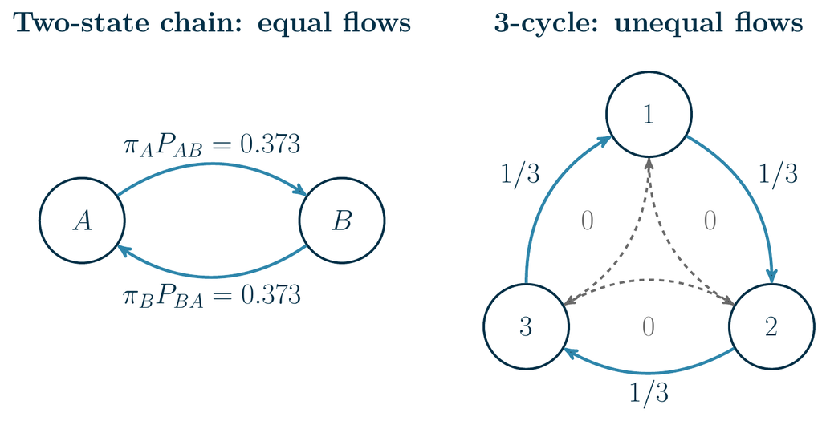

- Two-state: $\mathbf{P} = \left(\begin{smallmatrix} 0.3 & 0.7 \\ 0.8 & 0.2 \end{smallmatrix}\right)$, $\boldsymbol\pi = \bigl(\tfrac{8}{15}, \tfrac{7}{15}\bigr)$.
- 3-cycle: $\mathbf{P} = \left(\begin{smallmatrix} 0 & 1 & 0 \\ 0 & 0 & 1 \\ 1 & 0 & 0 \end{smallmatrix}\right)$, $\boldsymbol\pi = \bigl(\tfrac13, \tfrac13, \tfrac13\bigr)$.
- $\pi_iP_{ij} = \pi_jP_{ji}$ for all $i, j$; on a continuous state space, $\pi(x)K(x, y) = \pi(y)K(y, x)$ for all $x \ne y$.
- Essentially, this says that flow from $x$ to $y$ equals flow from $y$ to $x$.
- Two-state chain: $\pi_AP_{AB} = \frac{8}{15}(0.7) = 0.373$ and $\pi_BP_{BA} = \frac{7}{15}(0.8) = 0.373$ on the two arrows.
- 3-cycle: flow $\frac13(1) = \frac13$ along the cycle (solid), 0 against it (dashed).
- Both distributions are stationary. Only the two-state chain balances the flow on each pair.

where flow: the probability of the move in one step, with $X_t \sim \pi$; $\pi_i$, $\pi(x)$: the distribution; $\mathbf{P}$, $P_{ij}$, $K(x, y)$: the transition matrix, its entries, and the density.

## Detailed Balance Implies Stationarity

- Recall: $\boldsymbol\pi$ is stationary if $\sum_i \pi_iP_{ij} = \pi_j$ for all $j$, or $\int \pi(x)K(x, y)\,dx = \pi(y)$ for all $y$. Apply detailed balance, then use that each row sums to 1:

$$\sum_i \pi_iP_{ij} = \sum_i \pi_jP_{ji} = \pi_j\sum_i P_{ji} = \boxed{\pi_j}$$

$$\int \pi(x)K(x, y)\,dx = \int \pi(y)K(y, x)\,dx = \pi(y)\int K(y, x)\,dx = \boxed{\pi(y)}$$

- Essentially, this says that balance on every pair gives balance in total.
- The recipe: build moves that balance pair by pair, a condition with no sum or integral, and $\pi$ is stationary.
- Detailed balance alone guarantees neither uniqueness nor convergence: irreducibility gives uniqueness, and aperiodicity on top gives convergence.

where $\pi_i$, $\pi(x)$: the distribution, as probabilities or a density; $P_{ij}$, $K(x, y)$: the transition probabilities and density, with $\sum_i P_{ji} = 1$ and $\int K(y, x)\,dx = 1$.

## The Metropolis Algorithm

**The Metropolis Algorithm**

Target $\pi$, known up to a constant. Symmetric proposal $q(y \mid x) = q(x \mid y)$. Start $X_0$ with $\pi(X_0) > 0$. For $t = 0, 1, 2, \ldots$:

1. Draw $Y \sim q(\cdot \mid X_t)$.
2. Compute $\alpha(X_t, Y) = \min\bigl(1, \pi(Y)/\pi(X_t)\bigr)$.
3. Draw $U \sim \Uniform(0, 1)$.
4. Set $X_{t+1} = Y$ if $U \le \alpha(X_t, Y)$, otherwise $X_{t+1} = X_t$.
- If $\pi(Y) \ge \pi(X_t)$: always accept. If $\pi(Y) < \pi(X_t)$: sometimes accept, with probability equal to the ratio.
- We only need the ratio: a posterior’s unknown constant cancels.
- Irreducibility: proposals must connect the support, $\{x : \pi(x) > 0\}$, to explore the entire posterior.
- An irreducible chain that can reject is aperiodic: a rejection keeps it in place, a self-loop.

where $\pi$: the target density; $q(y \mid x)$: the proposal density from $x$ to $y$; $X_t$: the state at time $t$; $Y$: the proposed value; $\alpha$: the acceptance probability; $U$: a uniform draw.

## Metropolis Satisfies Detailed Balance

- For $y \ne x$, $K(x, y) = q(y \mid x)\,\alpha(x, y)$. $K$ covers moves only: a rejection keeps the chain at $x$, with probability $r_{\text{rej}}(x) = 1 - \int K(x, y)\,dy$. A proposal with $\pi(y) = 0$ is rejected, so take $x$, $y$ with positive target density.
- $\pi(x)\,\alpha(x, y) = \pi(x)\min\bigl(1, \pi(y)/\pi(x)\bigr) = \min\bigl(\pi(x), \pi(y)\bigr)$, symmetric in $x$ and $y$. With $q$ symmetric too:

$$\pi(x)K(x, y) = q(y \mid x)\min\bigl(\pi(x), \pi(y)\bigr) = q(x \mid y)\min\bigl(\pi(y), \pi(x)\bigr) = \boxed{\pi(y)K(y, x)}$$

- With $X_t \sim \pi$, moves into $y$ plus stays at $y$ give the density of $X_{t+1}$ at $y$, so repeated states count as draws:

$$\int \pi(x)K(x, y)\,dx + \pi(y)\,r_{\text{rej}}(y) = \pi(y)\int K(y, x)\,dx + \pi(y)\,r_{\text{rej}}(y) = \boxed{\pi(y)}$$

- Essentially, this says that any symmetric proposal, with this acceptance step, leaves the target stationary.

where $\pi$: the target density; $q$: the proposal density; $\alpha(x, y) = \min(1, \pi(y)/\pi(x))$: the acceptance probability; $K(x, y)$: the density of a move from $x$ to $y$; $r_{\text{rej}}(x)$: the rejection probability at $x$; $X_t$: the state at time $t$.

# Closing

## Questions and Results

| Question | Property | Result | In MCMC |
| --- | --- | --- | --- |
| Exists? | positive recurrence (finite: always) | $\pi_i = 1/\E[\tau_i \mid X_0 = i]$ | proper target and detailed balance |
| Unique? | irreducibility | uniqueness theorem | proposal connects the support |
| Converges? | aperiodicity on top | Fundamental Theorem | rejections |
| Averages? | irreducible and positive recurrent | Ergodic Theorem | time averages estimate expectations |
| Accuracy? | geometric ergodicity | Markov chain CLT | ESS |

- In MCMC the logic runs in reverse: detailed balance makes the target stationary, so an irreducible chain is positive recurrent once the target is proper, $\int L(\theta)\,\pi_0(\theta)\,d\theta < \infty$.

where $\pi_i$: the stationary probability of state $i$; $\tau_i$: the return time to state $i$; ESS: the effective sample size; $L(\theta)$: the likelihood; $\pi_0(\theta)$: the prior density.

## What You Actually Do in Practice

- Pick a proposal that connects the support: irreducibility makes the target the only stationary distribution.
- Run several chains from dispersed starts: the Fundamental Theorem says the start is forgotten in the limit.
- Discard the first $B$ draws: at finite $t$ the start still matters.
- Report $\bar h_N$: the Ergodic Theorem.
- Report $\sigma_h/\sqrt{\text{ESS}}$: the Markov chain CLT.

where $B$: the number of draws discarded, the burn-in; $\bar h_N$: the average of $h$ over the $N$ draws kept; $\sigma_h$, ESS: estimated from those draws, with the sum over lags truncated.

## Notation

| Symbol | Meaning |
| --- | --- |
| $X_t$, $\mathcal{S}$, $N$ | state, state space, chain length |
| $\mathbf{P}$, $P_{ij}$ | transition matrix, entry |
| $(\mathbf{P}^t)_{ij}$ | $t$-step probability |
| $K(x, y)$ | transition density |
| $\boldsymbol\mu_t$, $\mu_t(x)$ | distribution of $X_t$ |
| $\boldsymbol\pi$, $\pi_i$, $\pi(x)$ | stationary distribution |
| $\pi(A)$ | its probability of the set $A$ |
| $\phi(y; m, s^2)$ | $\Normal(m, s^2)$ density at $y$ |

| Symbol | Meaning |
| --- | --- |
| $\tau_i$, $d(i)$ | return time, period of $i$ |
| $C(x)$, $r$ | geometric constant, rate |
| $h$, $\bar h_N$ | function of the state, average |
| $\sigma_h^2$, $\rho_k$ | $\Var_\pi(h(X))$, lag-$k$ correlation |
| $\kappa$, ESS | $1 + 2\sum_{k \ge 1}\rho_k$, $N/\kappa$ |
| $q(y \mid x)$, $Y$ | proposal density, value |
| $\alpha(x, y)$ | acceptance probability |
| $r_{\text{rej}}(x)$ | rejection probability |
| $\rho$, $\epsilon_t$, $\sigma^2$ | AR(1): coefficient, noise, variance |

## Punchlines, and What Comes Next

- MCMC trades independent draws from the target for dependent draws from a chain with the target as its stationary distribution.
- Positive recurrence, irreducibility, and aperiodicity answer existence, uniqueness, and convergence: the Fundamental Theorem.
- Time averages converge without aperiodicity, and the effective sample size says how accurate they are.
- Detailed balance is the recipe. Metropolis satisfies it using only a ratio of the target.

An ergodic Markov chain forgets where it started, and its averages settle on expectations under its stationary distribution. Metropolis builds a chain whose stationary distribution is the posterior, from nothing more than a ratio of the unnormalized target.

Next: Metropolis in practice and Metropolis–Hastings, then Gibbs sampling and Hamiltonian Monte Carlo, then Stan.